# Predicting earnings from census data

## Fit a CART model using cp=0.002

What is the prediction accuracy on the test set?

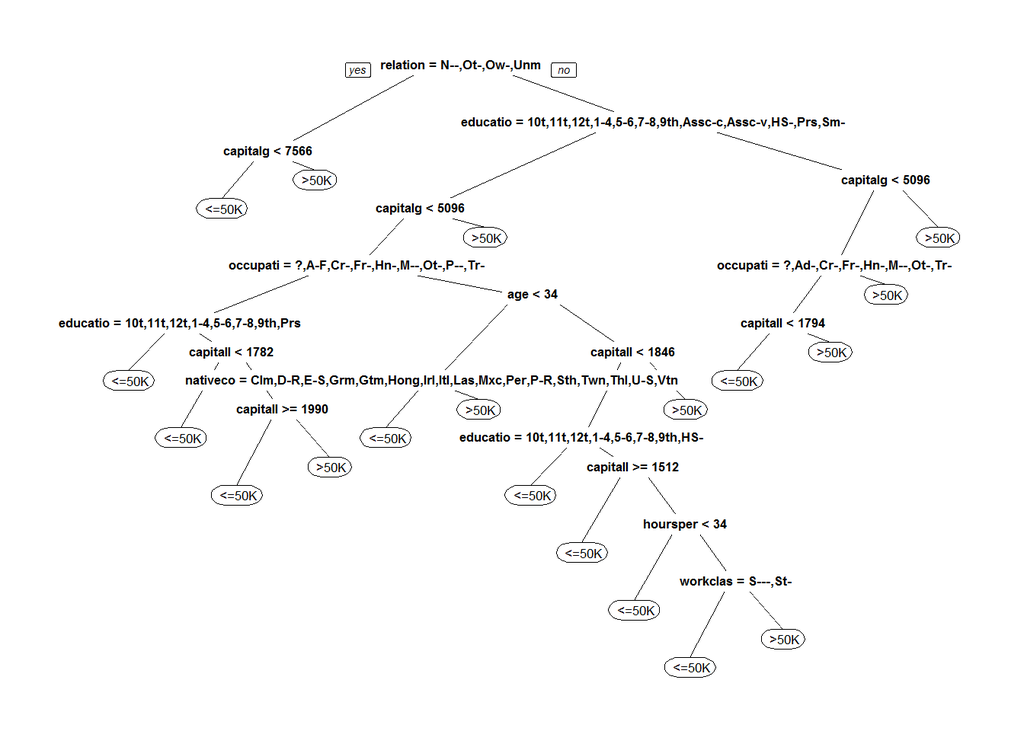

```r
censustree2 <- rpart(over50k ~ ., data= train, method="class", cp =0.002)
prp(censustree2)
```

```r
#Make predictions
pred.censustree2 <- predict(censustree2, newdata=test)
t1 <- table(test$over50k, pred.censustree2[ ,2]>0.5)
t1
```

```
##
##          FALSE TRUE
##    <=50K  9178  535
##    >50K   1240 1838
```

```r
accuracy <- sum(diag(t1))/margin.table(t1)
accuracy
```

```
## [1] 0.8612306
```

```r
#Another way to do the confusion matrix would be
pred.censustree2 <- predict(censustree2, newdata=test, type="class")
t1 <- table(test$over50k, pred.censustree2)
t1
```

```
##         pred.censustree2
##           <=50K  >50K
##    <=50K   9178   535
##    >50K    1240  1838
```

```r
accuracy <- sum(diag(t1))/margin.table(t1)
accuracy #0.8612306
```

```
## [1] 0.8612306
```

Compared to the original accuracy using the default value of cp, this new CART model is an improvement, and so we should clearly favor this new model over the old one – or should we? Plot the CART tree for this model. We see that there are 18 splits. This highlights one important tradeoff in building predictive models. **By tuning cp, we improved our accuracy by over 1%, but our tree became significantly more complicated**. In some applications, such an improvement in accuracy would be worth the loss in interpretability. In others, we may prefer a less accurate model that is simpler to understand and describe over a more accurate – but more complicated – model.